# OBJECTIF 3 : Accessibilité avec R et Open Street Map

AFROMPA’R Bouaké 2025

Auteur·rice

Claude Grasland & Bamba Vakaramoko

Date de publication

2025-03-28

Reprenant un cours dispensé lors de l’école d’été CIST 2023 au Bénin par C. Grasland et B. Vakaramoko et intitulé [Distance et accessibilité](https://ee2023.netlify.app/modules/spa2_dis), nous voudrions montrer lors de l’école d’été Afromap’R 2025 quelques exemples d’utilisation de la base de données OSRM et du package R correspondant pour effectuer des calculs de distance routière ou de distance-temps.

Les mesures de distance sont intéressantes en elle-même pour comparer les régions les plus accessibles ou les moins accessibles d’un territoire. Mais elles sont également utiles comme variables explicatives d’autres phénomènes de nature sociale ou économique. On peut par exemple mettre en rapport la distance à une capitale nationale ou un chef-lieu de région avec le niveau de développement d’une commune.

## (1) LE PROJET OSRM

Le **projet OSRM** (Open SOurce Routing Machine) est un service de routage utilisant les données d’OpenStreetMap (OSM). Le package permet de calculer des routes, des matrices de distances, des isochrones en utilisant s’appuyant sur le réseau routier d’OSM. Il est accessible en ligne sur le site web suivant

https://project-osrm.org/

Le **package R OSRM** est une interface créée par Timothée Giraud, Robin Cura, Matthieu Viry et Robin Lovelace qui permet d’accéder à l’API OSRM depuis un programme R et ainsi d’effectuer automatiquement les calculs précédents. Il est accessible sur le CRAN et possède une documentation avec des exemples :

https://cran.r-project.org/web/packages/osrm/index.html

La dernière version d’OSRM a fait l’objet de révisions importantes par Timothée Giraud et qui a publié récemment un article à ce sujet dans *JOSS* qui est la revue de référence pour les package R.

- **Giraud, Timothée. 2022.** “osrm: Interface Between R and the OpenStreetMap-Based Routing Service OSRM.” *Journal of Open Source Software* 7 (78): 4574. https://doi.org/10.21105/joss.04574.

L’objectif de l’exercice proposé lors de l’école d’été CIST2023 était d’essayer d’appliquer ce package ORSM au calcul des distances entre les chefs-lieux des 14 districts de Côte d’Ivoire, afin de vérifier si les résultats obtenus sont approximativement justes et ne comportent pas trop d’erreur. Il est en effet possible que l’analyse souffre de problèmes lorsque la couverture OSM n’est pas complète ou de qualité insuffisante.

## (2) PREPARATION DES DONNEES

### Données géométriques

Nous utiliserons trois fonds de cartes de type shapefile (enregistrés au format sf de R dans des fichiers de type .RDS) qui servent uniquement ici à repérer les positions des points ou à cartographier les résultats des analyses. Il s’agit :

- du contour des 14 districts (source : OCHA)
- du contour des 33 régions (source : OCHA)
- des routes principales (source : OSM & OCHA)

```r
# Contour du pays
map_state<-readRDS(file ="data/exo_access/CIV.RDS")
map_state_proj<-st_transform(map_state, crs = 2043)

# Districts
map_districts<-readRDS(file = "data/exo_access/CIV_DISTRICTS.RDS")
map_districts_proj<-st_transform(map_districts, crs = 2043)

# Regions
map_regions<-readRDS(file = "data/exo_access/CIV_REGIONS.RDS")
map_regions_proj<-st_transform(map_regions, crs = 2043)

# Routes (sélection des niveaux 1 et 2)
map_roads<-readRDS(file = "data/exo_access/CIV_ROADS.RDS") %>% filter(highway !="tertiary")
map_roads$niveau <-as.factor(map_roads$highway)
levels(map_roads$niveau)<-c("Autoroute","niveau 1", "niveau 2", "niveau 1")
map_roads$size<-4-as.numeric(map_roads$niveau)
map_roads<-map_roads %>% arrange(size)
map_roads_proj<-st_transform(map_roads, crs = 2043)
```

On peut en proposer une visualisation statique à l’aide du package mapsf :

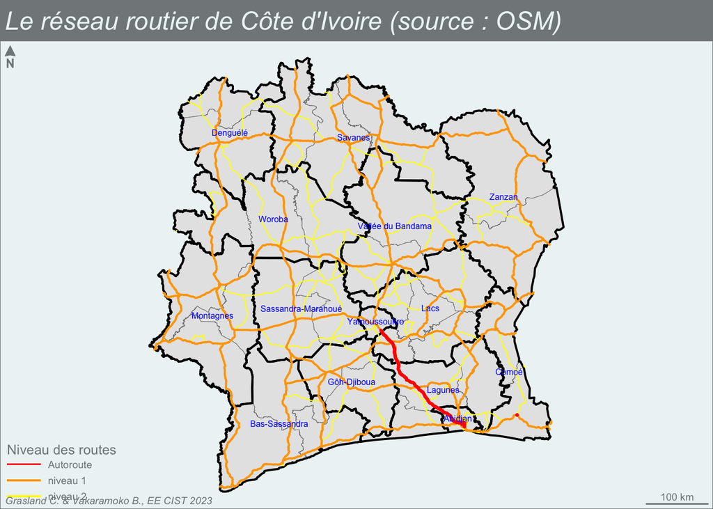

```r
mf_theme(x = "agolalight")
mf_map(map_regions_proj,col="gray90",border="gray50",lwd=0.5)

mf_map(map_districts_proj,
       col=NA,
       border="black",
       lwd=2,add=T)

mf_map(map_roads_proj,
       type = "typo",
       var = "niveau",
       lwd= map_roads_proj$size,
       pal=c("red","orange","yellow"),
       add=T,
       leg_title = "Niveau des routes")

mf_label(map_districts_proj,
         var = "DIS_NOM",
         col = "blue",cex = 0.5)

mf_layout(title = "Le réseau routier de Côte d'Ivoire (source : OSM)",
          credits = "Grasland C. & Vakaramoko B., EE CIST 2023",
          frame = T,scale = T, arrow = T)
```

### Position des centroïdes des districts

Le calcul du centroïde des régions ou des districts est possible dans R avec la fonction `st_centroid()` du package **sf**. Il conduit à placer des points à un emplacement différent de celui des chef-lieux administratifs puisque ces derniers ne sont pas forcément situé au centre géométrique de leur unité administrative. Du coup les points correspondant aux centroïdes risquent d’être situés à l’écart du réseau routier ce qui va conduire à des erreurs de calcul lorsqu’on voudra estimer les distances. Par exemple, le centroïde du district de Woroba ne se situe pas sur une route principale ou même secondaire.Quand au centroïde du district de la vallée du Bandama, il est bien sur une route mais très au nord du chef-lieu de Bouaké qui est un véritable carrefour routier vers l’ensemble du pays.

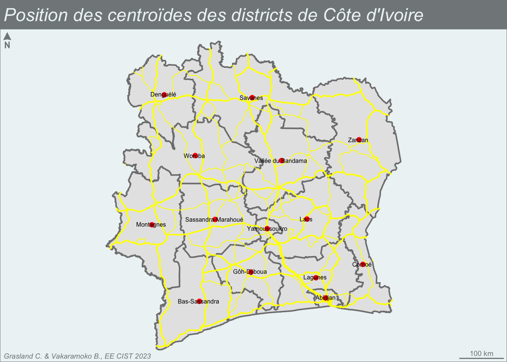

```r
map_districts_ctr <- st_centroid(map_districts,of_largest_polygon = T, quiet=T)
map_districts_ctr_proj <- st_transform(map_districts_ctr, crs = 2043)

mf_theme(x = "agolalight")

mf_map(map_districts_proj,
       col="gray90",
       border="gray50",
       lwd=2)

mf_map(map_roads_proj,
       var = "niveau",
       lwd= map_roads_proj$size,
       col="yellow",
       add=T)

mf_map(map_districts_ctr_proj,
       pch= 20,
       col="red",
       border="yellow",
       lwd=1,
       cex = 1.3,
       add=T)

mf_label(map_districts_ctr_proj,
         var = "DIS_NOM",
         col = "black",cex = 0.5,overlap = F)


mf_layout(title = "Position des centroïdes des districts de Côte d'Ivoire",
          credits ="Grasland C. & Vakaramoko B., EE CIST 2023",
          frame = T,scale = T, arrow = T)
```

### Importation ou saisie des coordonnées des chefs-lieux de district

Pour obtenir des distances plus pertinentes, nous devons donc importer les coordonnées de longitude et de latitude des chef-lieux de districts entre lesquelles on souhaite mesurer des distances routières. Nous disposons pour cela de deux solutions :

```r
coo <-read.table(file = "data/exo_access/DIS_CHEF.csv", header=T, sep=";", dec=",")
kable(coo,caption = "Coordonnées des chefs lieux de districts de Côte d'Ivoire")
```

Coordonnées des chefs lieux de districts de Côte d’Ivoire

| DIS_CODE | DIS_NOM | DIS_CTR | DIS_CTR_LON | DIS_CTR_LAT |
| --- | --- | --- | --- | --- |
| CI.CM | Comoé | Abengourou | -3.49700 | 6.74000 |
| CI.AB | Abidjan | Abidjan | -4.02044 | 5.32374 |
| CI.ZZ | Zanzan | Bondoukou | -2.80300 | 8.03900 |
| CI.VB | Vallée du Bandama | Bouaké | -5.05000 | 7.69800 |
| CI.LG | Lagunes | Dabou | -4.37800 | 5.32000 |
| CI.SM | Sassandra-Marahoué | Daloa | -6.45500 | 6.87600 |
| CI.LC | Lacs | Dimbokro | -4.70700 | 6.65300 |
| CI.GD | Gôh-Djiboua | Gagnoa | -5.95900 | 6.13300 |
| CI.SV | Savanes | Korhogo | -5.63100 | 9.46200 |
| CI.MG | Montagnes | Man | -7.54800 | 7.40300 |
| CI.DN | Denguélé | Odienné | -7.56400 | 9.50300 |
| CI.BS | Bas-Sassandra | San-Pédro | -6.67000 | 4.75600 |
| CI.WR | Woroba | Séguéla | -6.67300 | 7.96300 |
| CI.YM | Yamoussoukro | Yamoussoukro | -5.26300 | 6.80700 |

A la différence des centroïdes,les chefs lieux de régions se superposent parfaitement sur le réseau routier dont ils constituent logiquement les principaux carrefours :

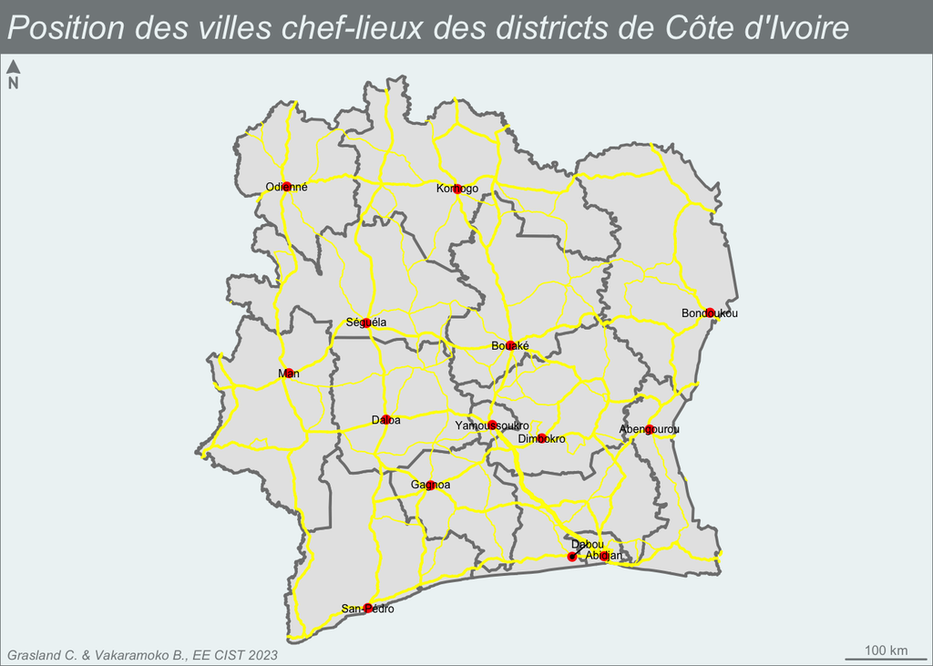

```r
map_districts_chef <- st_as_sf(coo, coords = c("DIS_CTR_LON","DIS_CTR_LAT"))
st_crs(map_districts_chef)<-4326
map_districts_chef_proj <- st_transform(map_districts_chef, crs = 2043)


mf_theme(x = "agolalight")

mf_map(map_districts_proj,
       col="gray90",
       border="gray50",
       lwd=2)

mf_map(map_roads_proj,
       var = "niveau",
       lwd= map_roads_proj$size,
       col="yellow",
       add=T)

mf_map(map_districts_chef_proj,
       pch= 20,
       col="red",
       border="yellow",
       lwd=1,
       cex = 1.3,
       add=T)

mf_label(map_districts_chef_proj,
         var = "DIS_CTR",
         col = "black",cex = 0.5, overlap = F)


mf_layout(title = "Position des villes chef-lieux des districts de Côte d'Ivoire",
          credits = "Grasland C. & Vakaramoko B., EE CIST 2023",
          frame = T,scale = T, arrow = T)
```

### Sauvegarde des fichiers

Nous sauvegardons les nouveaux fichiers créés au cours de cette étape sous deux formes différentes : en coordonnées latitude longitude (EPSG 4326) et en coordonnées projetées (EPSG 2043).

```r
saveRDS(map_districts_ctr,"data/exo_access/CIV_DISTRICTS_CTR_4326.RDS")
saveRDS(map_districts_ctr_proj,"CIV/CIV_DISTRICTS_CTR_2043.RDS")

saveRDS(map_districts_chef,"data/exo_access/CIV_DISTRICTS_CHEF_4326.RDS")
saveRDS(map_districts_chef_proj,"data/exo_access/CIV_DISTRICTS_CHEF_2043.RDS")

saveRDS(map_roads,"data/exo_access/CIV_ROADS_4326.RDS")
saveRDS(map_roads_proj,"data/exo_access/CIV_ROADS_2043.RDS")
```

## (3) CALCUL DE MATRICES DE DISTANCE

### Calcul des distances à vol d’oiseau

Le calcul des distances à vol d’oiseau (à la surface de la Terre) s’effectue très facilement à l’aide de la fonction `st_distance()` du package sf. Il faut juste faire attention à bientransformer le tableau obtenu en matrice avec la fonction `class()` puis à rajouter les noms de lignes et de colonnes.

```r
dist_eu<-as.matrix(st_distance(map_districts_chef))/1000
class(dist_eu)<-"matrix"
row.names(dist_eu)<-map_districts$DIS_CTR
colnames(dist_eu)<-substr(map_districts$DIS_CTR,1,3)
kable(dist_eu, digits=0, caption="Distance à vol d'oiseau entre chefs-lieux de districts de Côte d'Ivoire")
```

Distance à vol d’oiseau entre chefs-lieux de districts de Côte d’Ivoire

|  | Abi | San | Abe | Odi | Gag | Dim | Dab | Man | Dal | Kor | Bou | Ség | Yam | Bon |
| --- | --- | --- | --- | --- | --- | --- | --- | --- | --- | --- | --- | --- | --- | --- |
| Abidjan | 0 | 168 | 163 | 202 | 186 | 327 | 134 | 280 | 383 | 453 | 543 | 415 | 376 | 195 |
| San-Pédro | 168 | 0 | 331 | 287 | 40 | 320 | 166 | 233 | 493 | 453 | 607 | 300 | 415 | 215 |
| Abengourou | 163 | 331 | 0 | 250 | 349 | 423 | 260 | 408 | 349 | 528 | 548 | 562 | 426 | 304 |
| Odienné | 202 | 287 | 250 | 0 | 275 | 180 | 122 | 201 | 206 | 277 | 342 | 373 | 181 | 102 |
| Gagnoa | 186 | 40 | 349 | 275 | 0 | 288 | 153 | 197 | 481 | 420 | 583 | 262 | 388 | 192 |
| Dimbokro | 327 | 320 | 423 | 180 | 288 | 0 | 195 | 99 | 302 | 134 | 317 | 237 | 123 | 132 |
| Dabou | 134 | 166 | 260 | 122 | 153 | 195 | 0 | 150 | 328 | 324 | 446 | 303 | 261 | 64 |
| Man | 280 | 233 | 408 | 201 | 197 | 99 | 150 | 0 | 372 | 225 | 414 | 172 | 218 | 107 |
| Daloa | 383 | 493 | 349 | 206 | 481 | 302 | 328 | 372 | 0 | 311 | 212 | 536 | 202 | 298 |
| Korhogo | 453 | 453 | 528 | 277 | 420 | 134 | 324 | 225 | 311 | 0 | 234 | 310 | 115 | 261 |
| Bouaké | 543 | 607 | 548 | 342 | 583 | 317 | 446 | 414 | 212 | 234 | 0 | 537 | 197 | 392 |
| Séguéla | 415 | 300 | 562 | 373 | 262 | 237 | 303 | 172 | 536 | 310 | 537 | 0 | 357 | 276 |
| Yamoussoukro | 376 | 415 | 426 | 181 | 388 | 123 | 261 | 218 | 202 | 115 | 197 | 357 | 0 | 202 |
| Bondoukou | 195 | 215 | 304 | 102 | 192 | 132 | 64 | 107 | 298 | 261 | 392 | 276 | 202 | 0 |

### Calcul de matrices de distance et temps routier avec `osrmTable()`

La fonction demande les coordonnées de latitue et longitude des lieux pour lesquels on veut calculer les distances routières. On peut les fournir via un tableau (data.frame) ou via un objet de type spatial feature (sf) à condition que ce dernier soit en projection ESPG 4326 (c’est-à-dire non projeté). Voyons ici le premier cas à titre d’exemple :

On prépare un data.frame ne contenant que les coordonnées de longitude (en première colonne) et latitude (en deuxième colonne). Le nom des colonnes n’a pas d’importance mais il faut qu’il y en ait exactement deux et que la première corresponde bien aux longitudes et la seconde aux latitudes (en degrés décimaux). Il est en revanche important d’ajouter des noms de lignes au tableau pour pouvoir les retouver sur les marges de la matrice de distance.

```r
dis_chef<-read.table("data/exo_access/DIS_CHEF.csv", header=T, sep=";", dec=",")
coo<-dis_chef[,4:5]
row.names(coo)<-dis_chef$DIS_CTR
kable(coo,caption = "Fichier de coordonnées pour osrm (type data.frame ou matrix)")
```

Fichier de coordonnées pour osrm (type data.frame ou matrix)

|  | DIS_CTR_LON | DIS_CTR_LAT |
| --- | --- | --- |
| Abengourou | -3.49700 | 6.74000 |
| Abidjan | -4.02044 | 5.32374 |
| Bondoukou | -2.80300 | 8.03900 |
| Bouaké | -5.05000 | 7.69800 |
| Dabou | -4.37800 | 5.32000 |
| Daloa | -6.45500 | 6.87600 |
| Dimbokro | -4.70700 | 6.65300 |
| Gagnoa | -5.95900 | 6.13300 |
| Korhogo | -5.63100 | 9.46200 |
| Man | -7.54800 | 7.40300 |
| Odienné | -7.56400 | 9.50300 |
| San-Pédro | -6.67000 | 4.75600 |
| Séguéla | -6.67300 | 7.96300 |
| Yamoussoukro | -5.26300 | 6.80700 |

On peut alors effectuer le calcul de la matrice de distance routière soit en temps (“duration”), soit en kilomètre (“distance”) soit les deux à la fois (solution la plus simple). On récupère une liste qui comporte les deux matrices de distance ainsi que les coordonnées d’origine et de destination des lieux entr lesquels on a calculé les distances. Les temps routiers sont en minutes et les distances routières en mètres.

```r
dist <- osrmTable(coo, measure = c("duration", "distance"))
```

On procède ensuite à l’extraction des résultats sous la forme de matrices que l’on peut exprimer dans une autre unité de mesure (par exemple convertir les mètres en kilomètres). On en profite pour les symétriser car il peut arriver que la distance soit légèrement plus grande dans une des deux directions

```r
dist_km <- as.matrix(dist$distances)/1000
dist_km<-(dist_km+t(dist_km))/2
kable(dist_km,
      caption="Distance routière entre chefs-lieux de districts de Côte d'Ivoire (en km)",
      digits=0,
      col.names = substr(colnames(dist_km),1,3))
```

Distance routière entre chefs-lieux de districts de Côte d’Ivoire (en km)

|  | Abe | Abi | Bon | Bou | Dab | Dal | Dim | Gag | Kor | Man | Odi | San | Ség | Yam |
| --- | --- | --- | --- | --- | --- | --- | --- | --- | --- | --- | --- | --- | --- | --- |
| Abengourou | 0 | 205 | 196 | 291 | 235 | 385 | 161 | 324 | 506 | 571 | 738 | 523 | 510 | 242 |
| Abidjan | 205 | 0 | 398 | 347 | 47 | 378 | 236 | 273 | 563 | 564 | 795 | 334 | 503 | 235 |
| Bondoukou | 196 | 398 | 0 | 405 | 429 | 579 | 355 | 517 | 521 | 765 | 753 | 716 | 596 | 435 |
| Bouaké | 291 | 347 | 405 | 0 | 331 | 247 | 193 | 250 | 222 | 329 | 454 | 480 | 193 | 113 |
| Dabou | 235 | 47 | 429 | 331 | 0 | 361 | 220 | 238 | 547 | 548 | 778 | 288 | 486 | 218 |
| Daloa | 385 | 378 | 579 | 247 | 361 | 0 | 224 | 137 | 463 | 188 | 374 | 266 | 129 | 144 |
| Dimbokro | 161 | 236 | 355 | 193 | 220 | 224 | 0 | 163 | 410 | 410 | 641 | 391 | 349 | 81 |
| Gagnoa | 324 | 273 | 517 | 250 | 238 | 137 | 163 | 0 | 467 | 275 | 536 | 231 | 264 | 141 |
| Korhogo | 506 | 563 | 521 | 222 | 547 | 463 | 410 | 467 | 0 | 431 | 233 | 697 | 294 | 330 |
| Man | 571 | 564 | 765 | 329 | 548 | 188 | 410 | 275 | 431 | 0 | 264 | 404 | 137 | 330 |
| Odienné | 738 | 795 | 753 | 454 | 778 | 374 | 641 | 536 | 233 | 264 | 0 | 666 | 246 | 561 |
| San-Pédro | 523 | 334 | 716 | 480 | 288 | 266 | 391 | 231 | 697 | 404 | 666 | 0 | 394 | 389 |
| Séguéla | 510 | 503 | 596 | 193 | 486 | 129 | 349 | 264 | 294 | 137 | 246 | 394 | 0 | 269 |
| Yamoussoukro | 242 | 235 | 435 | 113 | 218 | 144 | 81 | 141 | 330 | 330 | 561 | 389 | 269 | 0 |

```r
dist_mn <- as.matrix(dist$durations)
dist_mn<-(dist_mn+t(dist_mn))/2
kable(dist_mn,
      caption="Temps routier entre chefs-lieux de districts de Côte d'Ivoire (en minutes)",
      digits=0,
      col.names = substr(colnames(dist_km),1,3))
```

Temps routier entre chefs-lieux de districts de Côte d’Ivoire (en minutes)

|  | Abe | Abi | Bon | Bou | Dab | Dal | Dim | Gag | Kor | Man | Odi | San | Ség | Yam |
| --- | --- | --- | --- | --- | --- | --- | --- | --- | --- | --- | --- | --- | --- | --- |
| Abengourou | 0 | 195 | 191 | 296 | 222 | 364 | 159 | 311 | 459 | 555 | 672 | 488 | 478 | 227 |
| Abidjan | 195 | 0 | 381 | 251 | 48 | 302 | 174 | 235 | 413 | 493 | 626 | 314 | 416 | 165 |
| Bondoukou | 191 | 381 | 0 | 409 | 408 | 550 | 346 | 498 | 494 | 742 | 708 | 675 | 634 | 414 |
| Bouaké | 296 | 251 | 409 | 0 | 260 | 216 | 156 | 228 | 187 | 400 | 400 | 435 | 246 | 87 |
| Dabou | 222 | 48 | 408 | 260 | 0 | 312 | 184 | 241 | 423 | 503 | 636 | 269 | 426 | 175 |
| Daloa | 364 | 302 | 550 | 216 | 312 | 0 | 207 | 137 | 379 | 195 | 399 | 244 | 121 | 139 |
| Dimbokro | 159 | 174 | 346 | 156 | 184 | 207 | 0 | 155 | 318 | 398 | 531 | 358 | 321 | 70 |
| Gagnoa | 311 | 235 | 498 | 228 | 241 | 137 | 155 | 0 | 391 | 286 | 526 | 211 | 254 | 146 |
| Korhogo | 459 | 413 | 494 | 187 | 423 | 379 | 318 | 391 | 0 | 427 | 216 | 597 | 273 | 250 |
| Man | 555 | 493 | 742 | 400 | 503 | 195 | 398 | 286 | 427 | 0 | 246 | 393 | 155 | 330 |
| Odienné | 672 | 626 | 708 | 400 | 636 | 399 | 531 | 526 | 216 | 246 | 0 | 633 | 279 | 463 |
| San-Pédro | 488 | 314 | 675 | 435 | 269 | 244 | 358 | 211 | 597 | 393 | 633 | 0 | 361 | 350 |
| Séguéla | 478 | 416 | 634 | 246 | 426 | 121 | 321 | 254 | 273 | 155 | 279 | 361 | 0 | 253 |
| Yamoussoukro | 227 | 165 | 414 | 87 | 175 | 139 | 70 | 146 | 250 | 330 | 463 | 350 | 253 | 0 |